# R Notebook - Phone Data Project - Bryan Honeck 02.08.2021

This data was taken from a fictional problem located on the Kaggle website-an online data science community. The problem involves a businessman who is attempting to start up his own phone company. He has been gathering data on thousands of different types of phones over the years. His goal is to be able to predict what price range a phone is in given the remaining 20 attributes listed in the structure of this data frame (i.e. battery capacity, phone weight, RAM, etc.).

```r
#phone.data <- train

head(phone.data)
```

|  | battery_power | blue | clock_speed | dual_sim | fc | four_g | int_memory | m_dep | mobile_wt | n_cores | pc | px_height | px_width | ram | sc_h | sc_w | talk_time | three_g | touch_screen | wifi | price_range |
| --- | --- | --- | --- | --- | --- | --- | --- | --- | --- | --- | --- | --- | --- | --- | --- | --- | --- | --- | --- | --- | --- |
| 1 | 842 | No | 2.2 | No | 1 | No | 7 | 0.6 | 188 | 2 | 2 | 20 | 756 | 2549 | 9 | 7 | 19 | No | No | Yes | Cheap |
| 2 | 1021 | Yes | 0.5 | Yes | 0 | Yes | 53 | 0.7 | 136 | 3 | 6 | 905 | 1988 | 2631 | 17 | 3 | 7 | Yes | Yes | No | Expensive |
| 3 | 563 | Yes | 0.5 | Yes | 2 | Yes | 41 | 0.9 | 145 | 5 | 6 | 1263 | 1716 | 2603 | 11 | 2 | 9 | Yes | Yes | No | Expensive |
| 4 | 615 | Yes | 2.5 | No | 0 | No | 10 | 0.8 | 131 | 6 | 9 | 1216 | 1786 | 2769 | 16 | 8 | 11 | Yes | No | No | Expensive |
| 5 | 1821 | Yes | 1.2 | No | 13 | Yes | 44 | 0.6 | 141 | 2 | 14 | 1208 | 1212 | 1411 | 8 | 2 | 15 | Yes | Yes | No | Cheap |
| 6 | 1859 | No | 0.5 | Yes | 3 | No | 22 | 0.7 | 164 | 1 | 7 | 1004 | 1654 | 1067 | 17 | 1 | 10 | Yes | No | No | Cheap |

It would be good to check and see if there is any missing data, just in case.

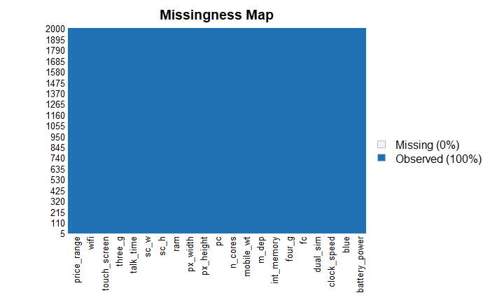

```r
library(Amelia)

missmap(phone.data)
```

```r
str(phone.data)
```

```
'data.frame':   2000 obs. of  21 variables:
 $ battery_power: int  842 1021 563 615 1821 1859 1821 1954 1445 509 ...
 $ blue         : Factor w/ 2 levels "No","Yes": 1 2 2 2 2 1 1 1 2 2 ...
 $ clock_speed  : num  2.2 0.5 0.5 2.5 1.2 0.5 1.7 0.5 0.5 0.6 ...
 $ dual_sim     : Factor w/ 2 levels "No","Yes": 1 2 2 1 1 2 1 2 1 2 ...
 $ fc           : int  1 0 2 0 13 3 4 0 0 2 ...
 $ four_g       : Factor w/ 2 levels "No","Yes": 1 2 2 1 2 1 2 1 1 2 ...
 $ int_memory   : int  7 53 41 10 44 22 10 24 53 9 ...
 $ m_dep        : num  0.6 0.7 0.9 0.8 0.6 0.7 0.8 0.8 0.7 0.1 ...
 $ mobile_wt    : int  188 136 145 131 141 164 139 187 174 93 ...
 $ n_cores      : int  2 3 5 6 2 1 8 4 7 5 ...
 $ pc           : int  2 6 6 9 14 7 10 0 14 15 ...
 $ px_height    : int  20 905 1263 1216 1208 1004 381 512 386 1137 ...
 $ px_width     : int  756 1988 1716 1786 1212 1654 1018 1149 836 1224 ...
 $ ram          : int  2549 2631 2603 2769 1411 1067 3220 700 1099 513 ...
 $ sc_h         : int  9 17 11 16 8 17 13 16 17 19 ...
 $ sc_w         : int  7 3 2 8 2 1 8 3 1 10 ...
 $ talk_time    : int  19 7 9 11 15 10 18 5 20 12 ...
 $ three_g      : Factor w/ 2 levels "No","Yes": 1 2 2 2 2 2 2 2 2 2 ...
 $ touch_screen : Factor w/ 2 levels "No","Yes": 1 2 2 1 2 1 1 2 1 1 ...
 $ wifi         : Factor w/ 2 levels "No","Yes": 2 1 1 1 1 1 2 2 1 1 ...
 $ price_range  : Factor w/ 4 levels "Very Cheap","Cheap",..: 2 3 3 3 2 2 4 1 1 1 ...
```

Change 0s and 1s to Yes and No

```r
#phone.data$blue <- factor(phone.data$blue, levels=c(0,1), labels=c("No", "Yes"))
#phone.data$dual_sim <- factor(phone.data$dual_sim, levels=c(0,1), labels=c("No", "Yes"))
#phone.data$four_g <- factor(phone.data$four_g, levels=c(0,1), labels=c("No", "Yes"))
#phone.data$three_g <- factor(phone.data$three_g, levels=c(0,1), labels=c("No", "Yes"))
#phone.data$touch_screen <- factor(phone.data$touch_screen, levels=c(0,1), labels=c("No", "Yes"))
#phone.data$wifi <- factor(phone.data$wifi, levels=c(0,1), labels=c("No", "Yes"))
#phone.data$price_range <- factor(phone.data$price_range, levels=c(0,1, 2, 3), labels=c("Very Cheap", "Cheap", "Expensive", "Very Expensive"))
```

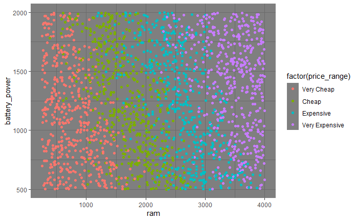

```r
library(ggplot2)
library(ggthemes)
library(plotly)

pl <- ggplot(phone.data, aes(x=ram, y=battery_power)) + geom_point(aes(color = factor(price_range))) + theme_dark()
pl
```

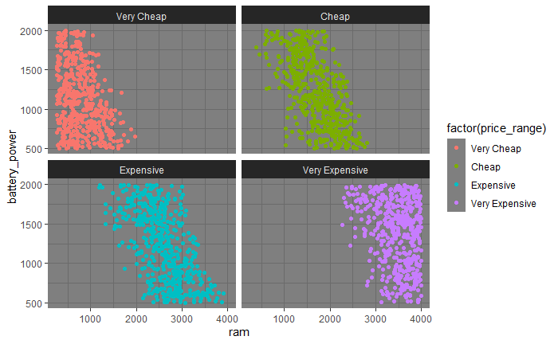

```r
pl.quad <- ggplot(phone.data, aes(x=ram, y=battery_power)) + geom_point(aes(color = factor(price_range))) + theme_dark() + facet_wrap(~price_range)
pl.quad
```

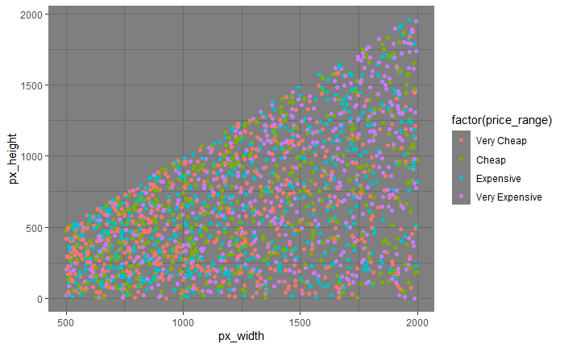

```r
pl2 <- ggplot(phone.data, aes(x=px_width, y=px_height)) + geom_point(aes(color = factor(price_range))) + theme_dark()
pl2
```

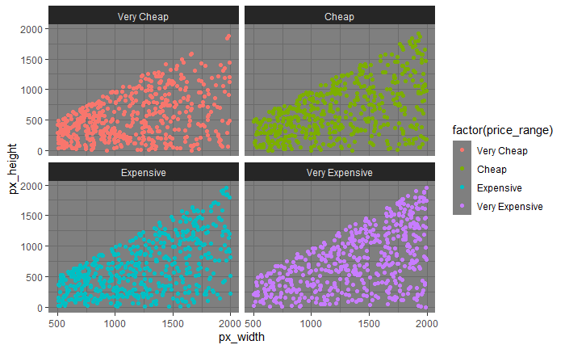

```r
pl2.quad <- ggplot(phone.data, aes(x=px_width, y=px_height)) + geom_point(aes(color = factor(price_range))) + theme_dark() + facet_wrap(~price_range)
pl2.quad
```

```r
NA
NA
```

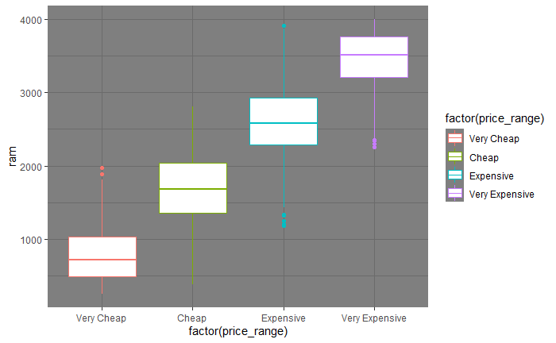

```r
pl3 <- ggplot(phone.data, aes(factor(price_range), ram)) + geom_boxplot(aes(color = factor(price_range))) + theme_dark()
pl3
```

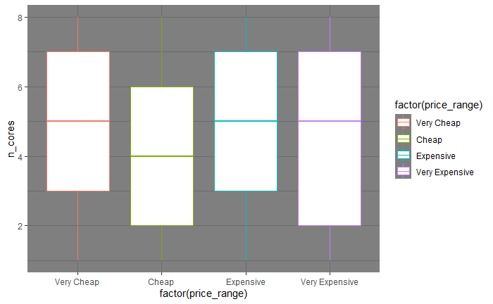

```r
pl4 <- ggplot(phone.data, aes(factor(price_range), n_cores)) + geom_boxplot(aes(color = factor(price_range))) + theme_dark()
pl4
```

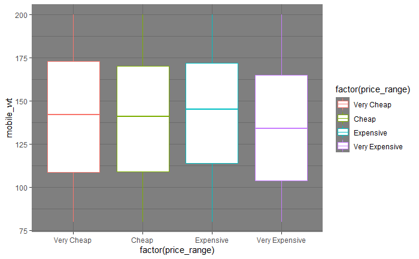

```r
pl4.a <- ggplot(phone.data, aes(factor(price_range), mobile_wt)) + geom_boxplot(aes(color = factor(price_range))) + theme_dark()
pl4.a
```

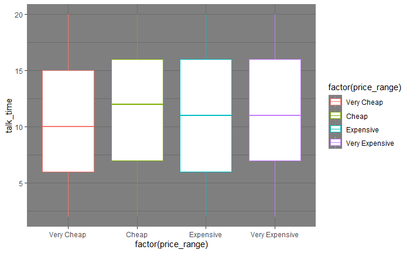

```r
pl4.b <- ggplot(phone.data, aes(factor(price_range), talk_time)) + geom_boxplot(aes(color = factor(price_range))) + theme_dark()
pl4.b
```

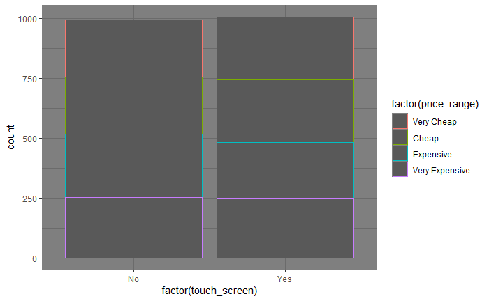

```r
pl5 <- ggplot(phone.data, aes(x=factor(touch_screen))) + geom_bar(aes(color = factor(price_range)))+ theme_dark() #+ facet_wrap(~touch_screen)
pl5
```

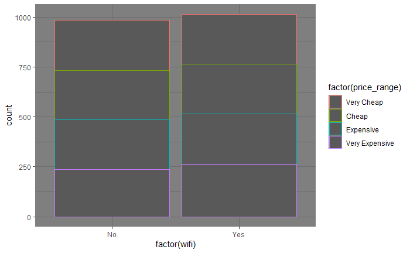

```r
pl6 <- ggplot(phone.data, aes(x=factor(wifi))) + geom_bar(aes(color = factor(price_range)))+ theme_dark()
pl6
```

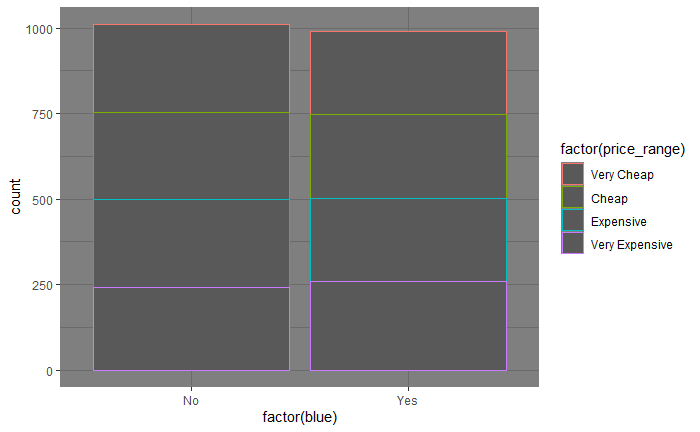

```r
pl6.a <- ggplot(phone.data, aes(x=factor(blue))) + geom_bar(aes(color = factor(price_range)))+ theme_dark()
pl6.a
```

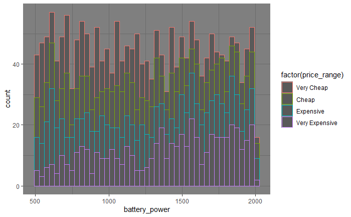

```r
pl7 <- ggplot(phone.data, aes(battery_power)) + geom_histogram(aes(color = factor(price_range)), bins = 45) + theme_dark() #+ facet_wrap(~price_range)
pl7
```

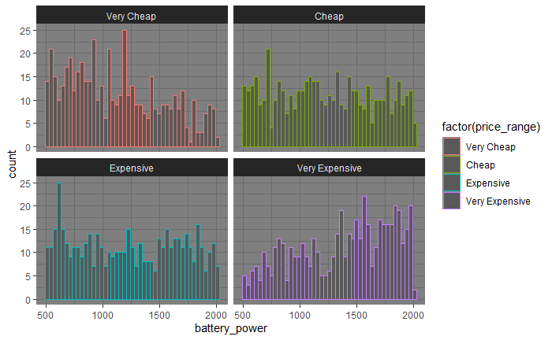

```r
pl7.quad <- ggplot(phone.data, aes(battery_power)) + geom_histogram(aes(color = factor(price_range)),bins = 45) + theme_dark() + facet_wrap(~price_range)
pl7.quad
```

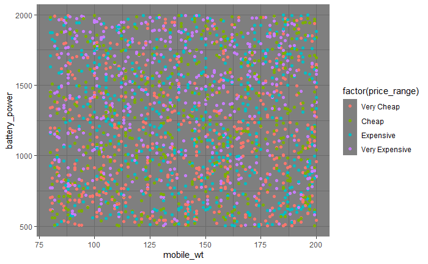

```r
pl8 <- ggplot(phone.data, aes(x=mobile_wt, y=battery_power)) + geom_point(aes(color = factor(price_range))) + theme_dark()
pl8
```

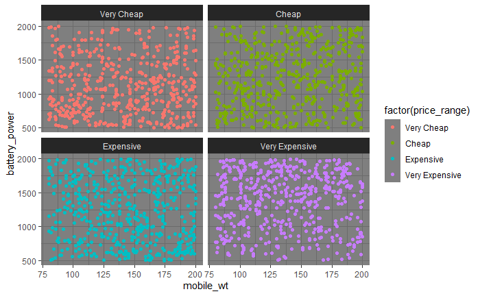

```r
pl8.quad <- ggplot(phone.data, aes(x=mobile_wt, y=battery_power)) + geom_point(aes(color = factor(price_range))) + theme_dark() + facet_wrap(~price_range)
pl8.quad
```

There is plenty to sift through with the visualizations above. Let’s look at some numerical attributes in the data.

The summary command gives quite a lot of information for each attribute.

```r
summary(phone.data)
```

```
 battery_power     blue       clock_speed    dual_sim         fc         four_g       int_memory
 Min.   : 501.0   No :1010   Min.   :0.500   No : 981   Min.   : 0.000   No : 957   Min.   : 2.00
 1st Qu.: 851.8   Yes: 990   1st Qu.:0.700   Yes:1019   1st Qu.: 1.000   Yes:1043   1st Qu.:16.00
 Median :1226.0              Median :1.500              Median : 3.000              Median :32.00
 Mean   :1238.5              Mean   :1.522              Mean   : 4.309              Mean   :32.05
 3rd Qu.:1615.2              3rd Qu.:2.200              3rd Qu.: 7.000              3rd Qu.:48.00
 Max.   :1998.0              Max.   :3.000              Max.   :19.000              Max.   :64.00
     m_dep          mobile_wt        n_cores            pc           px_height         px_width
 Min.   :0.1000   Min.   : 80.0   Min.   :1.000   Min.   : 0.000   Min.   :   0.0   Min.   : 500.0
 1st Qu.:0.2000   1st Qu.:109.0   1st Qu.:3.000   1st Qu.: 5.000   1st Qu.: 282.8   1st Qu.: 874.8
 Median :0.5000   Median :141.0   Median :4.000   Median :10.000   Median : 564.0   Median :1247.0
 Mean   :0.5018   Mean   :140.2   Mean   :4.521   Mean   : 9.916   Mean   : 645.1   Mean   :1251.5
 3rd Qu.:0.8000   3rd Qu.:170.0   3rd Qu.:7.000   3rd Qu.:15.000   3rd Qu.: 947.2   3rd Qu.:1633.0
 Max.   :1.0000   Max.   :200.0   Max.   :8.000   Max.   :20.000   Max.   :1960.0   Max.   :1998.0
      ram            sc_h            sc_w          talk_time     three_g    touch_screen  wifi
 Min.   : 256   Min.   : 5.00   Min.   : 0.000   Min.   : 2.00   No : 477   No : 994     No : 986
 1st Qu.:1208   1st Qu.: 9.00   1st Qu.: 2.000   1st Qu.: 6.00   Yes:1523   Yes:1006     Yes:1014
 Median :2146   Median :12.00   Median : 5.000   Median :11.00
 Mean   :2124   Mean   :12.31   Mean   : 5.767   Mean   :11.01
 3rd Qu.:3064   3rd Qu.:16.00   3rd Qu.: 9.000   3rd Qu.:16.00
 Max.   :3998   Max.   :19.00   Max.   :18.000   Max.   :20.00
         price_range
 Very Cheap    :500
 Cheap         :500
 Expensive     :500
 Very Expensive:500
```

We can actually create a model to predict what price range a phone will be in based on certain characteristics. There was some obvious clustering in one of the first plots produced in this document. We can use k-means clustering to see how similar some points are to others in their clusters.

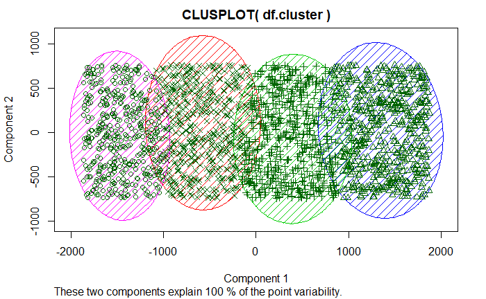

```r
library(cluster)
df.cluster <- data.frame(phone.data$ram, phone.data$battery_power)
cluster.price <- kmeans(df.cluster, 4, nstart = 20)

clusplot(df.cluster, cluster.price$cluster, color = TRUE, shade = TRUE, labels = 0, lines = 0)
```

```r
library(factoextra)
sil <- silhouette(cluster.price$cluster, dist(df.cluster))
fviz_silhouette(sil)
```

|  | cluster | size | ave.sil.width |
| --- | --- | --- | --- |
| 1 | 1 | 449 | 0.40 |
| 2 | 2 | 536 | 0.42 |
| 3 | 3 | 538 | 0.31 |
| 4 | 4 | 477 | 0.28 |

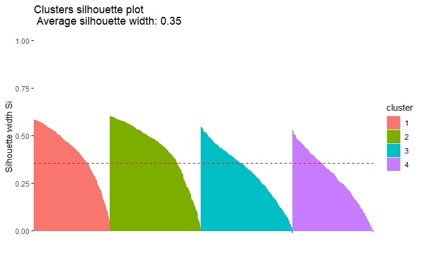

```r
NA
```

0.35 average silhouette width is not ideal, but it still shows there is pretty significant clustering. An average above 0.5 is what we would hope to find to make an even stronger case for the model. Based on the data frame that comes with our silhouette, we can actually see that clusters 1 and 2 were more sound than 3 and 4. There was some overlap in the model’s classification between those two clusters.

```r
table(cluster.price$cluster, phone.data$price_range)
```

```
    Very Cheap Cheap Expensive Very Expensive
  1        404    45         0              0
  2          0     0        97            439
  3          1   139       337             61
  4         95   316        66              0
```

You can actually run the animation of the kmeans clustering through each iteration, but this produces an unpleasant number of plots sometimes.

```r
#install.packages("animation")
#library(animation)
#kmeans.ani(df.cluster, 4)
```

This table is a good way to show the overlap in the model. It shows how the k-means clustering compares with the actual data. This helps our case in showing that RAM is a good predictor variable for finding a price range of a phone. As shown in the visualizations above, many of the other variables seem to have little or no effect on whether the phone is expensive or cheap.

For each of the plots, I have colored each individual phone by their categorical price range to make it easier on the viewer for interpreting the plots. The price range originally came in an integer form, from 0 to 3, with 0 being the least expensive and 3 being the most expensive. I updated all of the categorical variables in the data frame to make the visualizations more readable as well. For example, when examining the bar graph that shows the number of phones with or without touch screen capabilities, instead of having two integer values (0, 1), it makes significantly more sense to label them as factors (“No”, “Yes”). This is good practice for professional data visualization and also for readability in general.

Given each of the visualizations above, along with the statistical information retrieved, it is fair to say that RAM is the best predictor for the price range of a phone. This means that, given a phone’s RAM, we are able to give a relatively accurate prediction for what price range that phone may lie within. There was clear and obvious clustering occurring in that plot. Battery power appeared to have very little effect on the price range of the phones. As seen in the histograms involving battery power, the “Very Expensive” phones tend to have larger batteries than the “Very Cheap” devices, but this is not a significant predictor. As the phones had larger batteries, for each price range, the amount of RAM on the machine would drop. For instance, a device in the “Cheap” price range with a battery power of 500 would likely have between 1500 MB and 2500 MB of of RAM. On the other hand, another phone within the same “Cheap” price range with battery power of 2000 would most likely have between 750 MB and 1250 MB of RAM. This can clearly be seen by the pattern/clustering in the plot. Individually, each price range has a relatively linear correlation in relation to RAM.

In regards to screen sizes, there are no obvious correlations based on price range there. When split by price range, the data is almost uniform. The data had an interesting shape, however. Pixel height and pixel length have a certain cutoff; for example, a screen with a pixel width of 1000 will not have a pixel height greater than 1000. Based on the plot, all the data from this set follow this pattern.

Something interesting I noticed in the numerical summaries of each variable is that all but one of the categorical attributes had seemingly very even splits. The one variable that did not have an even split between its categories is the three_g attribute. 3 times as many phones in the dataset had 3G compared to those that did not. Every other categorical variable was split nearly perfectly down the line. In the case of the price range, each category had 500 observations. Given the background story behind the data, this makes sense.

Some other oddities within the data include the following: a device with a screen width of 0 was found. This must mean that the phone does not have a screen, otherwise, that tuple is invalid. On the other hand, the minimum screen height was 5. Something strange is occurring behind the scenes on the far minimum end of this attribute in the dataset. This would not have been brought to light without viewing the five-number summaries of this variable. Another oddity is the minimum pixel height found on a device turned out to be 0. This is questionable, much like the preceding few statements.